# Assignment 1 R Notebook

Dien Nguyen

# Install and load required packages

```r
if (!require("BiocManager", quietly = TRUE))
  install.packages("BiocManager")
if (!require("org.Hs.eg.db", quietly = TRUE))
  BiocManager::install("org.Hs.eg.db")
if (!require("dplyr", quietly = TRUE))
  install.packages("dplyr")
library(org.Hs.eg.db)
library(ggplot2)
library(dplyr)
library(edgeR)
```

# Introduction to the data

The data set under investigation is from a GEO (Gene Expression Omnibus) [accession](https://www.ncbi.nlm.nih.gov/geo/query/acc.cgi?acc=GSE144474) titled “Contribution of brain pericytes in blood-brain barrier (BBB) formation and maintenance: A transcriptomic study of cocultured human endothelial cells derived from hematopoietic stem cells”(Heymans et al. 2020).

The interaction of endothelial cells (ECs) and brain pericytes induces BBB characteristics in brain ECs during embryogenesis. Pericytes are a type of vascular cells embedded in the basement membrane, and is important for BBB functioning, so they can be used to differentiate stem cells into ECs and them BBB in vitro. However, the molecular events in BBB maturation are not fully understood.

This data set was interesting to me because I am interested in learning more about genes involved in stem cell differentiation, having previously done single-cell RNAseq analysis on induced pluripotent stem cells (iPSCs)-derived mature lung tissue. I am interested in seeing the similarities and differences in differentation processes in the lung and brain.

# Download data from GEO

```r
# load counts table from GEO
if (!("raw_counts_data.csv" %in% list.files())) {
  urld <- "https://www.ncbi.nlm.nih.gov/geo/download/?format=file&type=rnaseq_counts"
  path <- paste(urld, "acc=GSE144474", "file=GSE144474_raw_counts_GRCh38.p13_NCBI.tsv.gz", sep="&");
  raw_counts <- as.data.frame(data.table::fread(path, header=T, colClasses="integer"), rownames=1)

  # export data frame as csv file
  write.csv(raw_counts, "raw_counts_data.csv", row.names = FALSE)
} else {
  raw_counts <- read.csv("./raw_counts_data.csv")
}
```

# Assess data quality

There are three conditions. The control is the solo-cultured ECs. The test conditions are ECs co-cultured with human pericytes, and ECs co-cultured with bovine pericytes. For each condition, there are 3 samples, which are sampled at different timepoints, and for each timepoint there are three replicates. In total, there are 27 samples.

In the raw counts data set, the samples are encoded, so the column names have to be renamed to be easily interpreted.

```r
Samples <- c("GeneID", "Solo_0h_Rep1", "Solo_0h_Rep2", "Solo_0h_Rep3",
             "Solo_48h_Rep1", "Solo_48h_Rep2", "Solo_48h_Rep3",
             "Solo_96h_Rep1", "Solo_96h_Rep2", "Solo_96h_Rep3",
             "HumanCC_24h_Rep1", "HumanCC_24h_Rep2", "HumanCC_24h_Rep3",
             "HumanCC_48h_Rep1", "HumanCC_48h_Rep2", "HumanCC_48h_Rep3",
             "HumanCC_96h_Rep1", "HumanCC_96h_Rep2", "HumanCC_96h_Rep3",
             "BovineCC_24h_Rep1", "BovineCC_24h_Rep2", "BovineCC_24h_Rep3",
             "BovineCC_48h_Rep1", "BovineCC_48h_Rep2", "BovineCC_48h_Rep3",
             "BovineCC_96h_Rep1", "BovineCC_96h_Rep2", "BovineCC_96h_Rep3")

Samples <- factor(Samples, levels = unique(Samples))


colnames(raw_counts) <- Samples
```

## Read counts per sample

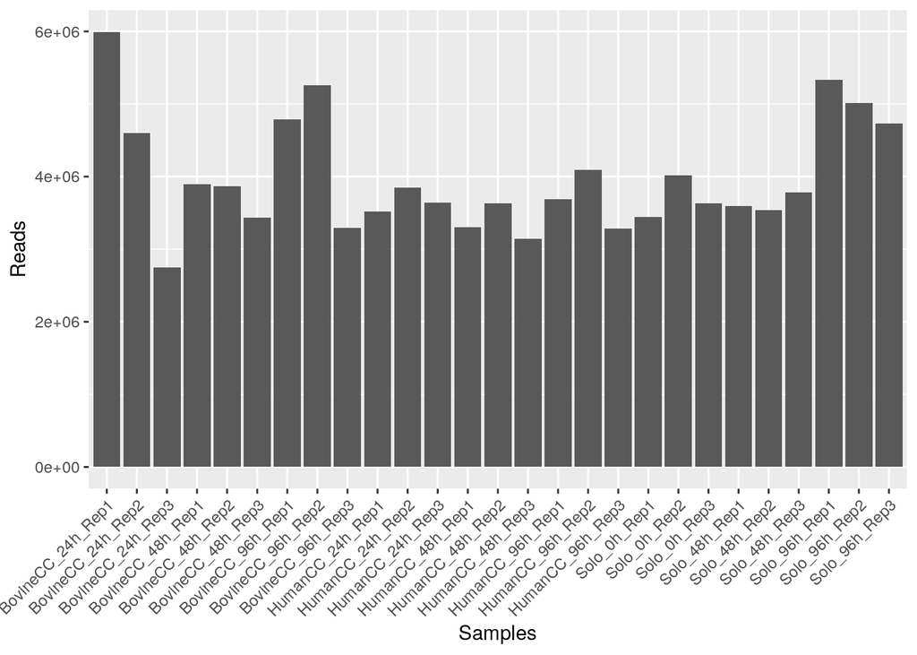

```r
# Calculate and plot read counts per sample
read_counts <- as.data.frame(colSums(raw_counts))
colnames(read_counts) <- c("Reads")
read_counts <- subset(read_counts, rownames(read_counts) != "GeneID")
read_counts$Samples <- row.names(read_counts)

# Plot read counts per sample
ggplot2::ggplot(read_counts, aes(x=Samples, y=Reads))+
   geom_bar(stat = "identity") +
   theme(axis.text.x = element_text(angle = 45, hjust = 1))
```

```r
mean(read_counts$Reads)
```

```
## [1] 3967311
```

The standard deviation percentage is:

```r
sd(read_counts$Reads) / mean(read_counts$Reads) * 100
```

```
## [1] 19.45043
```

## Genes detected per sample

Here, we plot the number of genes detected per sample using ggplot2 (Wickham 2016). The number of genes are consistent across all samples.

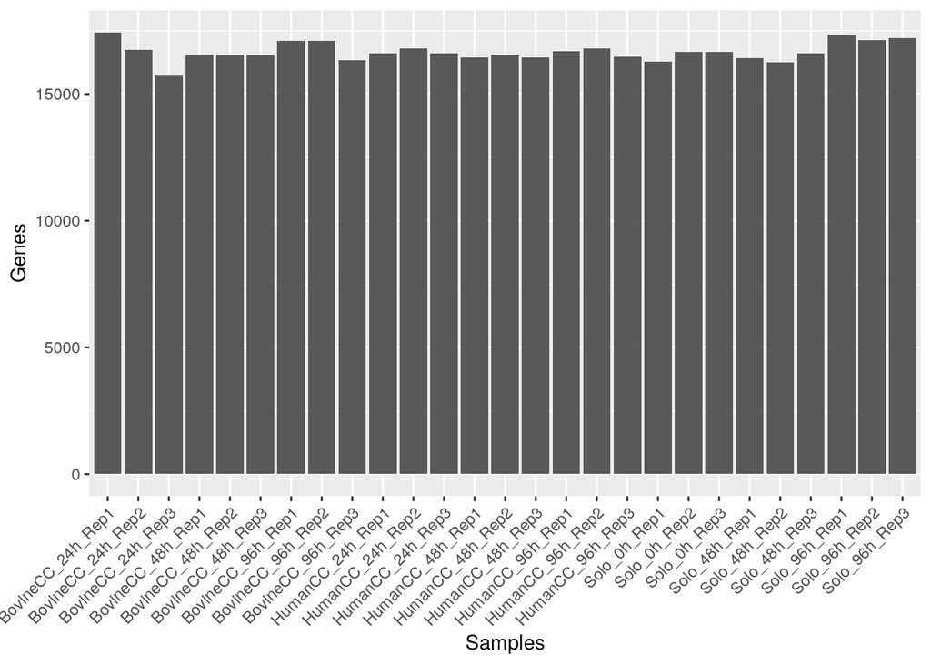

```r
# Calculate and plot genes per sample
gene_counts <- as.data.frame(colSums(raw_counts > 0))
colnames(gene_counts) <- c("Genes")
gene_counts <- subset(gene_counts, rownames(gene_counts) != "GeneID")
gene_counts$Samples <- row.names(gene_counts)

# Plot genes per sample
ggplot2::ggplot(gene_counts, aes(x=Samples, y=Genes)) +
   geom_bar(stat = "identity") +
   theme(axis.text.x = element_text(angle = 45, hjust = 1))
```

# Map to HUGO genes

There are a few data sets and R packages available to map different gene identifiers with each other, but org.Hs.eg.db is the one most suitable for mapping Entrez ID to HUGO symbols (M 2019). The dplyr package was used to join (map) the genes in our data set to the HUGO symbols (Wickham et al. 2023)

```r
# an object from org.Hs.EgSYMBOL that contains all mapping from entrez ID to
# HUGO symbol
x <- org.Hs.egSYMBOL
mapped_genes <- mappedkeys(x)
mapping <- as.data.frame(x[mapped_genes])

# change column name and data type to join
colnames(mapping)[1] <- "GeneID"
mapping$GeneID <- as.integer(mapping$GeneID)

# using left_join will result in NA for genes that cannot be mapped and retain
# the original data set
mapped_data <- dplyr::left_join(raw_counts, mapping, by = "GeneID")

unmapped_data <- subset(mapped_data, is.na(symbol))

mapped_data <- subset(mapped_data, !is.na(symbol))
```

Number of rows that were not mapped:

```r
nrow(unmapped_data)
```

```
## [1] 1641
```

Percentage of rows that were not mapped:

```r
(nrow(unmapped_data) / nrow(raw_counts)) * 100
```

```
## [1] 4.167513
```

Although only a small percentage of the genes were unmapped, we will store them and later do some analysis to determine whether they should be discarded or further investigated.

## Genes that are mapped to the same HUGO ID:

```r
# Find genes mapped to the same HUGO ID
duplicated_symbols <- mapped_data$symbol[duplicated(mapped_data$symbol)]
```

Rows with duplicates:

```r
mapped_data[mapped_data$symbol %in% duplicated_symbols,]
```

```
##         GeneID Solo_0h_Rep1 Solo_0h_Rep2 Solo_0h_Rep3 Solo_48h_Rep1
## 2031 107985614            0            0            0             0
## 2032 107985615            0            1            0             0
##      Solo_48h_Rep2 Solo_48h_Rep3 Solo_96h_Rep1 Solo_96h_Rep2 Solo_96h_Rep3
## 2031             0             0             0             0             0
## 2032             0             0             0             0             0
##      HumanCC_24h_Rep1 HumanCC_24h_Rep2 HumanCC_24h_Rep3 HumanCC_48h_Rep1
## 2031                0                0                0                0
## 2032                0                0                0                0
##      HumanCC_48h_Rep2 HumanCC_48h_Rep3 HumanCC_96h_Rep1 HumanCC_96h_Rep2
## 2031                0                0                0                0
## 2032                0                0                1                0
##      HumanCC_96h_Rep3 BovineCC_24h_Rep1 BovineCC_24h_Rep2 BovineCC_24h_Rep3
## 2031                0                 0                 0                 0
## 2032                0                 1                 0                 0
##      BovineCC_48h_Rep1 BovineCC_48h_Rep2 BovineCC_48h_Rep3 BovineCC_96h_Rep1
## 2031                 0                 0                 0                 1
## 2032                 0                 0                 0                 0
##      BovineCC_96h_Rep2 BovineCC_96h_Rep3    symbol
## 2031                 0                 0 TRNAV-CAC
## 2032                 0                 0 TRNAV-CAC
```

They both have low read counts, and and are likely going to be filtered out in the next step. Since they are very similar, only the first one was kept

```r
# Only keep the first one
mapped_data <- mapped_data[!duplicated(mapped_data$symbol), ]

# Set HUGO ID as rownames and remove unnecessary columns
rownames(mapped_data) <- mapped_data$symbol
mapped_data <- subset(mapped_data, select=c(-GeneID, -symbol))
```

## Visualize distribution before removing genes with row counts

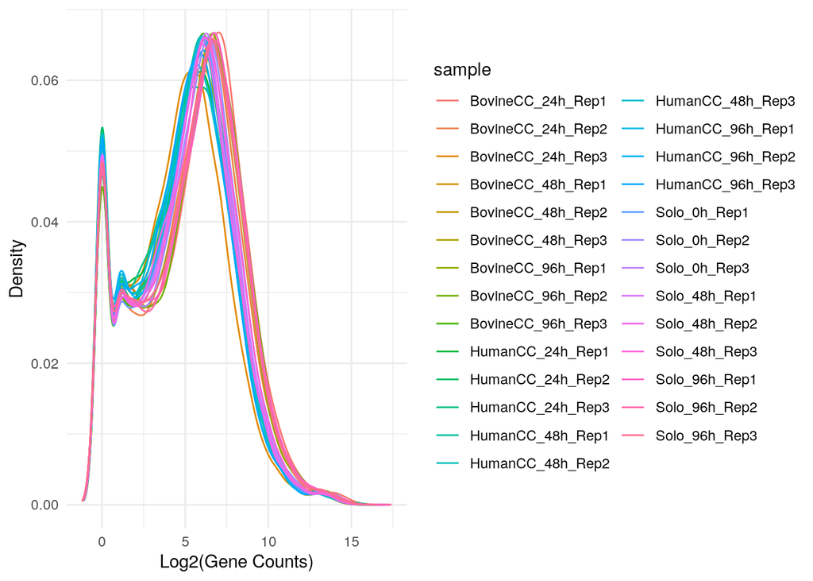

```r
counts_density <- apply(log2(mapped_data), 2, density)
density_df <- do.call(rbind, lapply(seq_along(counts_density), function(i) {
  data.frame(
    x = counts_density[[i]]$x,
    y = counts_density[[i]]$y,
    sample = colnames(mapped_data)[i]
  )
}))

# Create ggplot with density plots for each sample
ggplot2::ggplot(density_df, aes(x = x, y = y, color = sample)) +
  geom_line() +
  labs(x = "Log2(Gene Counts)", y = "Density", sample = "Samples") +
  theme_minimal()
```

Genes with low read counts were removed. The cpm function from the edgeR package was used to determining the counts per million for each gene (Robinson, McCarthy, and Smyth 2010).

```r
# Filter out genes with low read counts
min_num_samples <- 3
data_mtx <- as.matrix(mapped_data)
# get rid of low counts
keep = rowSums(edgeR::cpm(data_mtx) > 1) > min_num_samples
filtered_data_mtx = data_mtx[keep,]
```

Number and percentage of outliers removed:

```r
nrow(mapped_data) - nrow(filtered_data_mtx)
```

```
## [1] 23603
```

```r
((nrow(mapped_data) - nrow(filtered_data_mtx)) / nrow(mapped_data)) * 100
```

```
## [1] 62.55101
```

In the original paper, genes with low read counts were removed, but the thresholds were not specified. Here, although the thresholds set were not too stringent, more than 60% of the mapped genes were removed due to low read counts.

We will do the same for the unmapped data, to see if they are worth keeping for further analysis.

```r
unmapped_data <- subset(unmapped_data, select = c(-symbol))
unmapped_mtx <- as.matrix(unmapped_data)
keep = rowSums(edgeR::cpm(unmapped_mtx) > 1) > min_num_samples
unmapped_filtered_mtx <- unmapped_mtx[keep,]
```

## Genes that cannot be mapped to HUGO IDs

Percentage of unmapped rows that are filtered out:

```r
((nrow(unmapped_data) - nrow(unmapped_filtered_mtx)) / nrow(unmapped_data)) * 100
```

```
## [1] 68.49482
```

Since nearly 70% of the unmapped rows are eventually filtered out due to low read counts, we will not be doing further analysis of the unmapped rows.

## Visualize data set before and after removing outliers

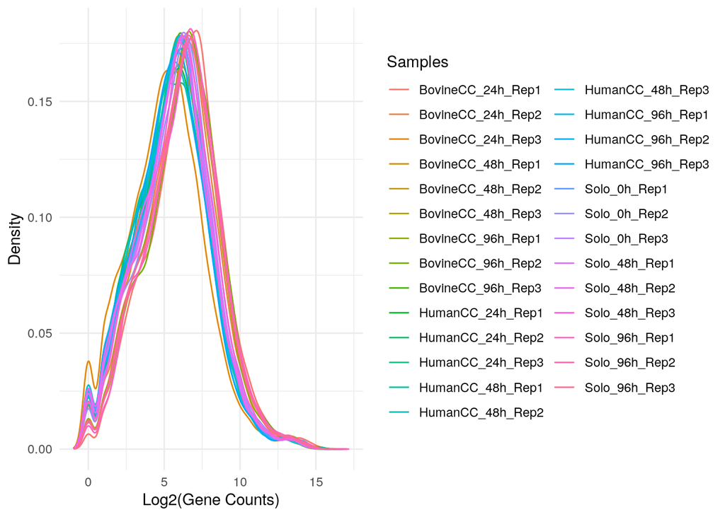

```r
counts_density <- apply(log2(filtered_data_mtx), 2, density)
density_df <- do.call(rbind, lapply(seq_along(counts_density), function(i) {
  data.frame(
    x = counts_density[[i]]$x,
    y = counts_density[[i]]$y,
    sample = colnames(mapped_data)[i]
  )
}))

# Create ggplot with density plots for each sample
ggplot2::ggplot(density_df, aes(x = x, y = y, color = sample)) +
  geom_line() +
  labs(x = "Log2(Gene Counts)", y = "Density", color = "Samples") +
  theme_minimal()
```

# Normalization

The data set was normalized using the Trimmed M Means (TMM) method, in the edgeR package (Robinson, McCarthy, and Smyth 2010). This method was chosen because its assumptions line up with the assumptions we made for this data set. Since the samples are quite similar in terms of cell type and the timepoints at which they were sampled, we expect most of the cells to be non-differentially expressed. We specified the group for each replicate and normalized by library size.

```r
condition_names <- factor(c("Solo_0h", "Solo_0h", "Solo_0h",
                            "Solo_48h", "Solo_48h", "Solo_48h",
                            "Solo_96h", "Solo_96h", "Solo_96h",
                            "HumanCC_24h", "HumanCC_24h", "HumanCC_24h",
                            "HumanCC_48", "HumanCC_48", "HumanCC_48",
                            "HumanCC_96h", "HumanCC_96h", "HumanCC_96h",
                            "BovineCC_24h", "BovineCC_24h", "BovineCC_24h",
                            "BovineCC_48h",  "BovineCC_48h",  "BovineCC_48h",
                            "BovineCC_96h", "BovineCC_96h", "BovineCC_96h"))
dge <- edgeR::DGEList(counts = filtered_data_mtx, group = condition_names)
dge_normalized <- edgeR::calcNormFactors(dge)
normalized_df <- edgeR::cpm(dge_normalized)
```

## Visualize data set after normalization

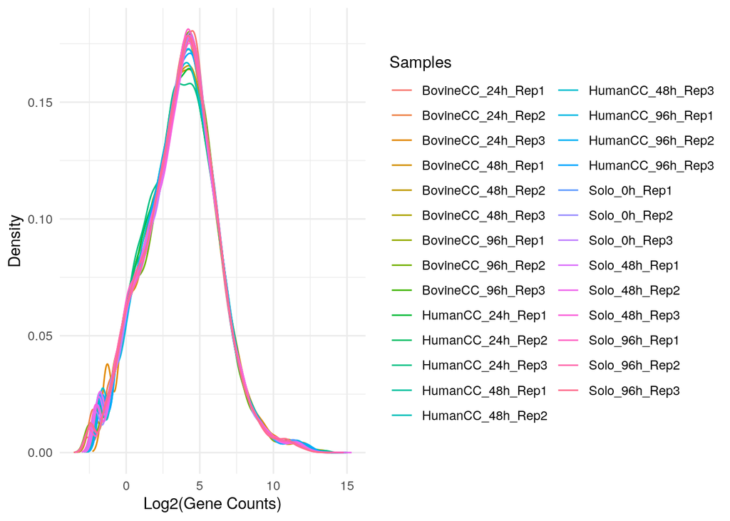

```r
counts_density <- apply(log2(normalized_df), 2, density)
density_df <- do.call(rbind, lapply(seq_along(counts_density), function(i) {
  data.frame(
    x = counts_density[[i]]$x,
    y = counts_density[[i]]$y,
    sample = colnames(normalized_df)[i]
  )
}))

# Create ggplot with density plots for each sample
ggplot2::ggplot(density_df, aes(x = x, y = y, color = sample)) +
  geom_line() +
  labs(x = "Log2(Gene Counts)", y = "Density", color = "Samples") +
  theme_minimal()
```

# Combine replicates using average

There are 3 replicates for each condition and timepoints. They were combined by calculating the average between them.

```r
condition_names <- c("Solo_0h", "Solo_48h", "Solo_96h",
                "HumanCC_24h", "HumanCC_48", "HumanCC_96h",
                "BovineCC_24h", "BovineCC_48h", "BovineCC_96h")
averaged_df <- c()

for (i in seq_along(condition_names)) {
  end_col <- i * 3
  start_col <- end_col - 2
  averaged_df <- cbind(averaged_df, rowMeans(normalized_df[,start_col:end_col]))
}
colnames(averaged_df) <- condition_names
```

# Final coverage

```r
sum(averaged_df)
```

```
## [1] 9020305
```

# Report questions

1. Why is this data set of interest to you?
2. What are the control and test conditions of the dataset?
3. How many samples in each of the conditions of your dataset?
4. Were there expression values that were not unique for specific genes?8 How did you handle these?
5. Were there expression values that could not be mapped to current HUGO symbols?
6. Were there any outliers in your dataset? How were they handled in the originating paper? How many outliers were removed?
7. How did you handle replicates?
8. What is the final coverage of your dataset? ```

Heymans, Marjolein, Ricardo Figueiredo, Lucie Dehouck, David Francisco, Yasuteru Sano, Fumitaka Shimizu, Takashi Kanda, et al. 2020. “Contribution of Brain Pericytes in Blood–Brain Barrier Formation and Maintenance: A Transcriptomic Study of Cocultured Human Endothelial Cells Derived from Hematopoietic Stem Cells.” *Fluids and Barriers of the CNS* 17 (1): 48. https://doi.org/10.1186/s12987-020-00208-1.

M, Carlson. 2019. *Org.hs.eg.db: Genome Wide Annotation for Human*. 10.18129/B9.bioc.org.Hs.eg.db.

Robinson, Mark D., Davis J. McCarthy, and Gordon K. Smyth. 2010. “edgeR: A Bioconductor Package for Differential Expression Analysis of Digital Gene Expression Data.” *Bioinformatics* 26 (1): 139–40. https://doi.org/10.1093/bioinformatics/btp616.

Wickham, Hadley. 2016. *Ggplot2: Elegant Graphics for Data Analysis*. Springer-Verlag New York. https://ggplot2.tidyverse.org.

Wickham, Hadley, Romain François, Lionel Henry, Kirill Müller, and Davis Vaughan. 2023. *Dplyr: A Grammar of Data Manipulation*. https://dplyr.tidyverse.org.